# python project of pooja

**GRADED PROJECT PYTHON**

**1.Import required libraries and read the provided dataset (youtube_dislike_dataset.csv) and retrieve top 5 and bottom records**

```python
#required libraries have been imported below
import numpy as np
import pandas as pd
import seaborn as sns
import matplotlib.pyplot as plt
import warnings
warnings.filterwarnings('ignore')
import sklearn
from sklearn.preprocessing import LabelEncoder,MinMaxScaler,StandardScaler
from sklearn .impute import KNNImputer,SimpleImputer
```

```python
# read the dataset
df=pd.read_csv("C:/Users/91990/Downloads/youtube_dislike_dataset (1).csv")
#it displays the all dataset
df
```

|  | video_id | title | channel_id | channel_title | published_at | view_count | likes | dislikes | comment_count | tags | description | comments |
| --- | --- | --- | --- | --- | --- | --- | --- | --- | --- | --- | --- | --- |
| 0 | --0bCF-iK2E | Jadon Sancho Magical Skills & Goals | UC6UL29enLNe4mqwTfAyeNuw | Bundesliga | 2021-07-01 10:00:00 | 1048888 | 19515 | 226 | 1319 | football soccer ftbol alemn Bundesliga season ... | Enjoy the best skills and goals from Jadon San... | Respect to Dortmund fans,must be sad losing hi... |
| 1 | --14w5SOEUs | Migos - Avalanche (Official Video) | UCGIelM2Dj3zza3xyV3pL3WQ | MigosVEVO | 2021-06-10 16:00:00 | 15352638 | 359277 | 7479 | 18729 | Migos Avalanche Quality Control Music/Motown R... | Watch the the official video for Migos - "Aval... | Migos just makes me want to live my live to th... |
| 2 | --40TEbZ9Is | Supporting Actress in a Comedy: 73rd Emmys | UClBKH8yZRcM4AsRjDVEdjMg | Television Academy | 2021-09-20 01:03:32 | 925281 | 11212 | 401 | 831 |  | Hannah Waddingham wins the Emmy for Supporting... | Hannah's energy bursts through any screen. Wel... |
| 3 | --4tfbSyYDE | JO1'YOUNG (JO1 ver.)' PERFORMANCE VIDEO | UCsmXiDP8S40uBeJYxvyulmA | JO1 | 2021-03-03 10:00:17 | 2641597 | 39131 | 441 | 3745 | PRODUCE101JAPAN JO1 TheSTAR STA... | JO1'YOUNG (JO1 ver.)' PERFORMANCE VIDEO\n\n---... | youngVer>< REN is really PERFECT. It's not ju... |
| 4 | --DKkzWVh-E | Why Retaining Walls Collapse | UCMOqf8ab-42UUQIdVoKwjlQ | Practical Engineering | 2021-12-07 13:00:00 | 715724 | 32887 | 367 | 1067 | retaining wall New Jersey highway Direct Conne... | One of the most important (and innocuous) part... | Keep up with all my projects here: https://pr... |
| ... | ... | ... | ... | ... | ... | ... | ... | ... | ... | ... | ... | ... |
| 37417 | zzd4ydafGR0 | Lil Tjay - Calling My Phone (feat. 6LACK) [Off... | UCEB4a5o_6KfjxHwNMnmj54Q | Lil Tjay | 2021-02-12 05:03:49 | 120408275 | 2180780 | 35871 | 81360 | Lil Tjay Steady Calling My Phone Calling My Ph... | Official video for "Calling My Phone" by Lil T... | 'DESTINED 2 WIN' OUT NOW !! https://liltjay.ln... |
| 37418 | zziBybeSAtw | PELICANS at LAKERS \| FULL GAME HIGHLIGHTS \| Ja... | UCWJ2lWNubArHWmf3FIHbfcQ | NBA | 2021-01-16 05:39:05 | 2841917 | 20759 | 1049 | 2624 | NBA G League Basketball game-0022000187 Lakers... | PELICANS at LAKERS \| FULL GAME HIGHLIGHTS \| Ja... | Montrezl Harrell is going crazy with the rebou... |
| 37419 | zzk09ESX7e0 | [MV] (MAMAMOO) - Where Are We Now | UCuhAUMLzJxlP1W7mEk0_6lA | MAMAMOO | 2021-06-02 09:00:10 | 13346678 | 720854 | 4426 | 90616 | MAMAMOO WAW WAW MAMAMOO WAW Where Are We Now... | [MV] (MAMAMOO) - Where Are We Now\n\nInstagra... | I honestly do not know why this song hit so ha... |
| 37420 | zzmQEb0Em5I | FELLIPE ESCUDERO- Master Podcast #12 | UC8NjnNWMsRqq11NYvHAQb1g | Master Podcast | 2020-10-20 20:59:30 | 252057 | 19198 | 1234 | 1471 | master masterpodcast lord lord vinheteiro z z ... | DOCTOR HAIR\nhttps://www.thedoctorhair.com/?fb... | Foi um prazer passar esta tarde com vocs debat... |
| 37421 | zzxPZwaA-8w | Gareth Bale brace secures dramatic comeback on... | UCEg25rdRZXg32iwai6N6l0w | Tottenham Hotspur | 2021-05-23 21:00:31 | 2252090 | 34063 | 868 | 2004 | Spurs Tottenham Hotspur Tottenham Leicester ... | Two minute highlights from Tottenham Hotspur's... | Thank you Kane for everything you have given t... |

37422 rows × 12 columns

```python
#retive top 5 records
df.head(5)
```

|  | video_id | title | channel_id | channel_title | published_at | view_count | likes | dislikes | comment_count | tags | description | comments |
| --- | --- | --- | --- | --- | --- | --- | --- | --- | --- | --- | --- | --- |
| 0 | --0bCF-iK2E | Jadon Sancho Magical Skills & Goals | UC6UL29enLNe4mqwTfAyeNuw | Bundesliga | 2021-07-01 10:00:00 | 1048888 | 19515 | 226 | 1319 | football soccer ftbol alemn Bundesliga season ... | Enjoy the best skills and goals from Jadon San... | Respect to Dortmund fans,must be sad losing hi... |
| 1 | --14w5SOEUs | Migos - Avalanche (Official Video) | UCGIelM2Dj3zza3xyV3pL3WQ | MigosVEVO | 2021-06-10 16:00:00 | 15352638 | 359277 | 7479 | 18729 | Migos Avalanche Quality Control Music/Motown R... | Watch the the official video for Migos - "Aval... | Migos just makes me want to live my live to th... |
| 2 | --40TEbZ9Is | Supporting Actress in a Comedy: 73rd Emmys | UClBKH8yZRcM4AsRjDVEdjMg | Television Academy | 2021-09-20 01:03:32 | 925281 | 11212 | 401 | 831 |  | Hannah Waddingham wins the Emmy for Supporting... | Hannah's energy bursts through any screen. Wel... |
| 3 | --4tfbSyYDE | JO1'YOUNG (JO1 ver.)' PERFORMANCE VIDEO | UCsmXiDP8S40uBeJYxvyulmA | JO1 | 2021-03-03 10:00:17 | 2641597 | 39131 | 441 | 3745 | PRODUCE101JAPAN JO1 TheSTAR STA... | JO1'YOUNG (JO1 ver.)' PERFORMANCE VIDEO\n\n---... | youngVer>< REN is really PERFECT. It's not ju... |
| 4 | --DKkzWVh-E | Why Retaining Walls Collapse | UCMOqf8ab-42UUQIdVoKwjlQ | Practical Engineering | 2021-12-07 13:00:00 | 715724 | 32887 | 367 | 1067 | retaining wall New Jersey highway Direct Conne... | One of the most important (and innocuous) part... | Keep up with all my projects here: https://pr... |

```python
#retreive the bottom 5 records
df.tail(5)
```

|  | video_id | title | channel_id | channel_title | published_at | view_count | likes | dislikes | comment_count | tags | description | comments |
| --- | --- | --- | --- | --- | --- | --- | --- | --- | --- | --- | --- | --- |
| 37417 | zzd4ydafGR0 | Lil Tjay - Calling My Phone (feat. 6LACK) [Off... | UCEB4a5o_6KfjxHwNMnmj54Q | Lil Tjay | 2021-02-12 05:03:49 | 120408275 | 2180780 | 35871 | 81360 | Lil Tjay Steady Calling My Phone Calling My Ph... | Official video for "Calling My Phone" by Lil T... | 'DESTINED 2 WIN' OUT NOW !! https://liltjay.ln... |
| 37418 | zziBybeSAtw | PELICANS at LAKERS \| FULL GAME HIGHLIGHTS \| Ja... | UCWJ2lWNubArHWmf3FIHbfcQ | NBA | 2021-01-16 05:39:05 | 2841917 | 20759 | 1049 | 2624 | NBA G League Basketball game-0022000187 Lakers... | PELICANS at LAKERS \| FULL GAME HIGHLIGHTS \| Ja... | Montrezl Harrell is going crazy with the rebou... |
| 37419 | zzk09ESX7e0 | [MV] (MAMAMOO) - Where Are We Now | UCuhAUMLzJxlP1W7mEk0_6lA | MAMAMOO | 2021-06-02 09:00:10 | 13346678 | 720854 | 4426 | 90616 | MAMAMOO WAW WAW MAMAMOO WAW Where Are We Now... | [MV] (MAMAMOO) - Where Are We Now\n\nInstagra... | I honestly do not know why this song hit so ha... |
| 37420 | zzmQEb0Em5I | FELLIPE ESCUDERO- Master Podcast #12 | UC8NjnNWMsRqq11NYvHAQb1g | Master Podcast | 2020-10-20 20:59:30 | 252057 | 19198 | 1234 | 1471 | master masterpodcast lord lord vinheteiro z z ... | DOCTOR HAIR\nhttps://www.thedoctorhair.com/?fb... | Foi um prazer passar esta tarde com vocs debat... |
| 37421 | zzxPZwaA-8w | Gareth Bale brace secures dramatic comeback on... | UCEg25rdRZXg32iwai6N6l0w | Tottenham Hotspur | 2021-05-23 21:00:31 | 2252090 | 34063 | 868 | 2004 | Spurs Tottenham Hotspur Tottenham Leicester ... | Two minute highlights from Tottenham Hotspur's... | Thank you Kane for everything you have given t... |

```python
# in dataset head of 5records as been retrived and tail of 5 records as been retrived one below the other. so head is the first 5 rows, bottom is last 5 rows.
print(df.head())
print(df.tail())
```

```
      video_id                                       title  \
0  --0bCF-iK2E        Jadon Sancho  Magical Skills & Goals
1  --14w5SOEUs          Migos - Avalanche (Official Video)
2  --40TEbZ9Is  Supporting Actress in a Comedy: 73rd Emmys
3  --4tfbSyYDE     JO1'YOUNG (JO1 ver.)' PERFORMANCE VIDEO
4  --DKkzWVh-E                Why Retaining Walls Collapse

                 channel_id          channel_title         published_at  \
0  UC6UL29enLNe4mqwTfAyeNuw             Bundesliga  2021-07-01 10:00:00
1  UCGIelM2Dj3zza3xyV3pL3WQ              MigosVEVO  2021-06-10 16:00:00
2  UClBKH8yZRcM4AsRjDVEdjMg     Television Academy  2021-09-20 01:03:32
3  UCsmXiDP8S40uBeJYxvyulmA                    JO1  2021-03-03 10:00:17
4  UCMOqf8ab-42UUQIdVoKwjlQ  Practical Engineering  2021-12-07 13:00:00

   view_count   likes  dislikes  comment_count  \
```

[output cut: 67 more lines]

**2.Check the info of the dataframe and write your inferences on data types and shape of the dataset.**

```python
#this is to check the inforamation of dataset displayed info of dataframe below
df.info()
```

```
<class 'pandas.core.frame.DataFrame'>
RangeIndex: 37422 entries, 0 to 37421
Data columns (total 12 columns):
 #   Column         Non-Null Count  Dtype
---  ------         --------------  -----
 0   video_id       37422 non-null  object
 1   title          37422 non-null  object
 2   channel_id     37422 non-null  object
 3   channel_title  37422 non-null  object
 4   published_at   37422 non-null  object
 5   view_count     37422 non-null  int64
 6   likes          37422 non-null  int64
 7   dislikes       37422 non-null  int64
 8   comment_count  37422 non-null  int64
 9   tags           37422 non-null  object
 10  description    37422 non-null  object
 11  comments       37264 non-null  object
dtypes: int64(4), object(8)
memory usage: 3.4+ MB
```

```python
#it is to check the how many rows and column in a dataset
df.shape
```

```
(37422, 12)
```

#### from the output of my inference are

- the column represents various attribute are video_id,title,channel_id,channel_title,published_at,view_count,likes dislikes comment_count,tags,description,comments
- the dataframe contains shape=37,422 rows and 12 columns
- object datatype are video_id,title,channel_id,channel_title,published_at,tags,description,comments
- int64 datatype are view_count,likes,dislikes,comment_count
- there are no most missing values except, comments columns there are 158 rest other are non null columns 37,264
- The view_count column has a wide range, with minimum and maximum values respectively
- The likes, dislikes, and comment_count columns also have a significant range, with high maximum values and relatively large standard deviations.
- The title column has a high number of unique values (37,113 out of 37,422), indicating diverse video titles.
- The channel_id and channel_title columns also have a high number of unique values, suggesting a large number of different channels.
- The tags and description columns have a relatively high number of unique values, indicating a wide variety of tags and video descriptions.
- The published_at column has a high number of unique values (36,772 out of 37,422), suggesting a diverse range of publishing dates.
- memory usage: 3.4+ MB

**3. Check for the Percentage of the missing values and drop or impute them.**

```python
#check for the missing values using a isnull method to find the missing values in dataframe and then use the sum() method to add the missing values of each column in the dataframe.
missing_values = df.isnull().sum()
missing_values
```

```
video_id           0
title              0
channel_id         0
channel_title      0
published_at       0
view_count         0
likes              0
dislikes           0
comment_count      0
tags               0
description        0
comments         158
dtype: int64
```

```python
#calcualte the percentage of missing values = divide the count of missing values by the total number of rows in the dataframe and multiply by 100 to get the percentage.
missing_percentage=(missing_values/len(df))*100
missing_percentage
```

```
video_id         0.000000
title            0.000000
channel_id       0.000000
channel_title    0.000000
published_at     0.000000
view_count       0.000000
likes            0.000000
dislikes         0.000000
comment_count    0.000000
tags             0.000000
description      0.000000
comments         0.422212
dtype: float64
```

```python
# Imputing of missing values: If the percentage of missing values is relatively low, then choose to impute them with appropriate values.Common imputation methods include filling with mean, median, mode, or using more advanced techniques like regression imputation.
# so i have taken a imutation method to fill the missing values i taken mode method to imute the missing values.
df.fillna(df.mode(). iloc[0], inplace = True)
print(df)
```

```
          video_id                                              title  \
0      --0bCF-iK2E               Jadon Sancho  Magical Skills & Goals
1      --14w5SOEUs                 Migos - Avalanche (Official Video)
2      --40TEbZ9Is         Supporting Actress in a Comedy: 73rd Emmys
3      --4tfbSyYDE            JO1'YOUNG (JO1 ver.)' PERFORMANCE VIDEO
4      --DKkzWVh-E                       Why Retaining Walls Collapse
...            ...                                                ...
37417  zzd4ydafGR0  Lil Tjay - Calling My Phone (feat. 6LACK) [Off...
37418  zziBybeSAtw  PELICANS at LAKERS | FULL GAME HIGHLIGHTS | Ja...
37419  zzk09ESX7e0                 [MV]  (MAMAMOO) - Where Are We Now
37420  zzmQEb0Em5I              FELLIPE ESCUDERO- Master Podcast  #12
37421  zzxPZwaA-8w  Gareth Bale brace secures dramatic comeback on...

                     channel_id          channel_title         published_at  \
0      UC6UL29enLNe4mqwTfAyeNuw             Bundesliga  2021-07-01 10:00:00
```

[output cut: 64 more lines]

```python
#so again i am using a isnull()method i.e,to know the null values has been imputed or not.so it is filled with a values and there is no null value present here.so the output is 0.so null value as values so it diplaying there's no null values
df.isnull().sum()
```

```
video_id         0
title            0
channel_id       0
channel_title    0
published_at     0
view_count       0
likes            0
dislikes         0
comment_count    0
tags             0
description      0
comments         0
dtype: int64
```

**4. Check the statistical summary of both numerical and categorical columns and write your inferences.**

```python
# so firstly i am checking with categorical columns which is the method is choose a select_dtypes is include object
obj_df = df.select_dtypes(include=object)
#it displays categorical column with default 5 rows of dataframe.
obj_df.head()
```

|  | video_id | title | channel_id | channel_title | published_at | tags | description | comments |
| --- | --- | --- | --- | --- | --- | --- | --- | --- |
| 0 | --0bCF-iK2E | Jadon Sancho Magical Skills & Goals | UC6UL29enLNe4mqwTfAyeNuw | Bundesliga | 2021-07-01 10:00:00 | football soccer ftbol alemn Bundesliga season ... | Enjoy the best skills and goals from Jadon San... | Respect to Dortmund fans,must be sad losing hi... |
| 1 | --14w5SOEUs | Migos - Avalanche (Official Video) | UCGIelM2Dj3zza3xyV3pL3WQ | MigosVEVO | 2021-06-10 16:00:00 | Migos Avalanche Quality Control Music/Motown R... | Watch the the official video for Migos - "Aval... | Migos just makes me want to live my live to th... |
| 2 | --40TEbZ9Is | Supporting Actress in a Comedy: 73rd Emmys | UClBKH8yZRcM4AsRjDVEdjMg | Television Academy | 2021-09-20 01:03:32 |  | Hannah Waddingham wins the Emmy for Supporting... | Hannah's energy bursts through any screen. Wel... |
| 3 | --4tfbSyYDE | JO1'YOUNG (JO1 ver.)' PERFORMANCE VIDEO | UCsmXiDP8S40uBeJYxvyulmA | JO1 | 2021-03-03 10:00:17 | PRODUCE101JAPAN JO1 TheSTAR STA... | JO1'YOUNG (JO1 ver.)' PERFORMANCE VIDEO\n\n---... | youngVer>< REN is really PERFECT. It's not ju... |
| 4 | --DKkzWVh-E | Why Retaining Walls Collapse | UCMOqf8ab-42UUQIdVoKwjlQ | Practical Engineering | 2021-12-07 13:00:00 | retaining wall New Jersey highway Direct Conne... | One of the most important (and innocuous) part... | Keep up with all my projects here: https://pr... |

```python
#so here we are seperating numerical columns which is choose a method select_dtypes is exclude the object will get the numerical columns.
num_df = df.select_dtypes(exclude=object)
#it only displays numerical columns of 5 rows
num_df.head()
```

|  | view_count | likes | dislikes | comment_count |
| --- | --- | --- | --- | --- |
| 0 | 1048888 | 19515 | 226 | 1319 |
| 1 | 15352638 | 359277 | 7479 | 18729 |
| 2 | 925281 | 11212 | 401 | 831 |
| 3 | 2641597 | 39131 | 441 | 3745 |
| 4 | 715724 | 32887 | 367 | 1067 |

```python
# descibe()is use to diplay all summary statistics of numerical columns and used a lambda function is used to display from scientific value to numerical values after decimal 2points of number will be displayed
stat_summary_numerical= df.describe().apply(lambda s: s.apply('{0:.2f}'.format))

#descibe() which is within brakets used a include=object is use to diplay all summary statistics of categorical columns
stat_summary_categorical=df.describe(include='object')

#printing the summary statistics of numerical columns
print("summary_statistics-numerical columns")
print(stat_summary_numerical)

#printing the summary statistics of categorical columns
print("summary_statistics-categorical columns")
print(stat_summary_categorical)
```

```
summary_statistics-numerical columns
          view_count        likes    dislikes comment_count
count       37422.00     37422.00    37422.00      37422.00
mean      5697837.84    166814.75     4989.86       9924.93
std      24266216.34    537567.03    30708.24     117100.25
min         20368.00         0.00        0.00          0.00
25%        512297.00     13233.50      281.00        900.00
50%       1319078.50     42330.50      796.00       2328.00
75%       3670231.25    130469.75     2461.75       6184.00
max    1322796924.00  31837675.00  2397733.00   16071029.00
summary_statistics-categorical columns
           video_id  title                channel_id        channel_title  \
count         37422  37422                     37422                37422
unique        37422  37113                     10961                10883
top     --0bCF-iK2E    www  UCNAf1k0yIjyGu3k9BwAg3lg  Sky Sports Football
freq              1     21                       533                  533

               published_at   tags description  \
count                 37422  37422       37422
unique                36772  28799       35630
top     2020-10-16 04:00:10
freq                      6   3817         589

                                                 comments
count                                               37422
unique                                              37264
top     \n\n\n\n\n\n\n\n\n\n\n\n\n\n\n\n\n\n\n\n\n\n\n...
freq                                                  159
```

the describe() is called on the DataFrame 'df' to generate summary statistics for both numerical and categorical columns. By default, describe() provides summary statistics for numerical columns, including count, mean, standard deviation, minimum value, 25th percentile, median (50th percentile), 75th percentile, and maximum value.include object method as been used to give each categorical columns will be executed and if we exclude object only numerical columns will be excuted or we can mention it as only describe() to execute numerical values.

The code then prints the summary statistics for both numerical and categorical columns separately.

### By analyzing the summary statistics,the following inferences are below:

- **For numerical columns**:the count of non-null values, which indicates the number of available data points for each column. The mean provides an average value, while the standard deviation measures the variability or spread of the data. The minimum and maximum values indicate the range of values in the column. The quartiles (25th, 50th, and 75th percentiles) give insights into the distribution of the data.could see above output represents all the values.
- **For categorical columns**: The count represents the number of non-null values in each column. The unique count indicates the number of distinct categories in each column. The top represents the most frequent category, and the frequency denotes the count of that category. By examining these statistics,the distribution and prevalence of different categories in the categorical columns could see above output represents all the values.

**5. Convert datatype of column published_at from object to pandas datetime.**

```python
#dataframe as df which is of published_at here the pd.to_datetime() function is used change the dtype of published_at from pandas

df['published_at']=pd.to_datetime(df['published_at'])

#here printing the updated of datatype is changed to datatime from pandas is displayed below
print(df.dtypes)
```

```
video_id                 object
title                    object
channel_id               object
channel_title            object
published_at     datetime64[ns]
view_count                int64
likes                     int64
dislikes                  int64
comment_count             int64
tags                     object
description              object
comments                 object
dtype: object
```

**6. Create a new column as 'published_month' using the column published_at (display the months only)**

```python
#To create a new column named 'published_month' using the 'published_at' column and extract only the months,used the dt.month attribute of the pandas datetime objects.

#'df' with the 'published_at' column of datetime type with the method dt.month

df['published_month']=df['published_at'].dt.month

# Print the updated DataFrame with the new 'published_month' column
print(df['published_month'])
```

```
0         7
1         6
2         9
3         3
4        12
         ..
37417     2
37418     1
37419     6
37420    10
37421     5
Name: published_month, Length: 37422, dtype: int64
```

```python
#To create a new column named 'published_year' using the 'published_at' column and extract only the years,used the dt.year attribute of the pandas datetime objects.

#'df' with the 'published_at' column of datetime type with the method dt.year

df['published_year']=df['published_at'].dt.year

# Print the updated DataFrame with the new 'published_year' column

print(df['published_year'])
```

```
0        2021
1        2021
2        2021
3        2021
4        2021
         ...
37417    2021
37418    2021
37419    2021
37420    2020
37421    2021
Name: published_year, Length: 37422, dtype: int64
```

```python
#To create a new column named 'published_date' using the 'published_at' column and extract only the date,used the dt.date attribute of the pandas datetime objects.

#'df' with the 'published_at' column of datetime type with the method dt.date
df['published_date']=df['published_at'].dt.date

# Print the updated DataFrame with the new 'published_date' column
print(df['published_date'])
```

```
0        2021-07-01
1        2021-06-10
2        2021-09-20
3        2021-03-03
4        2021-12-07
            ...
37417    2021-02-12
37418    2021-01-16
37419    2021-06-02
37420    2020-10-20
37421    2021-05-23
Name: published_date, Length: 37422, dtype: object
```

**7. Replace the numbers in the column published_month as names of the months i,e., 1 as 'Jan', 2 as 'Feb' and so on.....**

```python
# To replace the numbers in the 'published_month' column with the names of the months, i have taken a dictionary to map the numbers to their corresponding month names, and then used the replace() method of pandas DataFrame.
month_occur = { 1: 'Jan',2: 'Feb', 3: 'Mar',4: 'Apr',5: 'May',6: 'Jun',7: 'Jul',8: 'Aug',9: 'Sep',10: 'Oct',11: 'Nov',12: 'Dec'}

# replace numbers with month names using replace()

df['published_month'] = df['published_month'].replace(month_occur)

# Print the updated DataFrame with month names in the 'published_month' column
print(df['published_month'])
```

```
0        Jul
1        Jun
2        Sep
3        Mar
4        Dec
        ...
37417    Feb
37418    Jan
37419    Jun
37420    Oct
37421    May
Name: published_month, Length: 37422, dtype: object
```

**8. Find the number of videos published each month and arrange the months in a decreasing order based on the video count.**

```python
#display the first 5 rows
df.head()
```

|  | video_id | title | channel_id | channel_title | published_at | view_count | likes | dislikes | comment_count | tags | description | comments | published_month | published_year | published_date |
| --- | --- | --- | --- | --- | --- | --- | --- | --- | --- | --- | --- | --- | --- | --- | --- |
| 0 | --0bCF-iK2E | Jadon Sancho Magical Skills & Goals | UC6UL29enLNe4mqwTfAyeNuw | Bundesliga | 2021-07-01 10:00:00 | 1048888 | 19515 | 226 | 1319 | football soccer ftbol alemn Bundesliga season ... | Enjoy the best skills and goals from Jadon San... | Respect to Dortmund fans,must be sad losing hi... | Jul | 2021 | 2021-07-01 |
| 1 | --14w5SOEUs | Migos - Avalanche (Official Video) | UCGIelM2Dj3zza3xyV3pL3WQ | MigosVEVO | 2021-06-10 16:00:00 | 15352638 | 359277 | 7479 | 18729 | Migos Avalanche Quality Control Music/Motown R... | Watch the the official video for Migos - "Aval... | Migos just makes me want to live my live to th... | Jun | 2021 | 2021-06-10 |
| 2 | --40TEbZ9Is | Supporting Actress in a Comedy: 73rd Emmys | UClBKH8yZRcM4AsRjDVEdjMg | Television Academy | 2021-09-20 01:03:32 | 925281 | 11212 | 401 | 831 |  | Hannah Waddingham wins the Emmy for Supporting... | Hannah's energy bursts through any screen. Wel... | Sep | 2021 | 2021-09-20 |
| 3 | --4tfbSyYDE | JO1'YOUNG (JO1 ver.)' PERFORMANCE VIDEO | UCsmXiDP8S40uBeJYxvyulmA | JO1 | 2021-03-03 10:00:17 | 2641597 | 39131 | 441 | 3745 | PRODUCE101JAPAN JO1 TheSTAR STA... | JO1'YOUNG (JO1 ver.)' PERFORMANCE VIDEO\n\n---... | youngVer>< REN is really PERFECT. It's not ju... | Mar | 2021 | 2021-03-03 |
| 4 | --DKkzWVh-E | Why Retaining Walls Collapse | UCMOqf8ab-42UUQIdVoKwjlQ | Practical Engineering | 2021-12-07 13:00:00 | 715724 | 32887 | 367 | 1067 | retaining wall New Jersey highway Direct Conne... | One of the most important (and innocuous) part... | Keep up with all my projects here: https://pr... | Dec | 2021 | 2021-12-07 |

```python
#from datafarme of 'df' with the 'published_month' column here for video count of each month groupby method published_month and vedio_id then again count() method from pandas
videocount_eachmonth=df.groupby('published_month')['video_id'].count()

#prints the count of vedios of each month
print(videocount_eachmonth)

# here vedio count is sorted by taking the sorted_values method from pandas and ascending=False(which displays in decending order)
videocount_bysorted=videocount_eachmonth.sort_values(ascending=False)

#prints in decending order of video by each month of counts
print(videocount_bysorted)
```

```
published_month
Apr    2126
Aug    4262
Dec    3072
Feb    2137
Jan    2108
Jul    2340
Jun    2316
Mar    2258
May    2081
Nov    4851
Oct    4991
Sep    4880
Name: video_id, dtype: int64
published_month
Oct    4991
Sep    4880
Nov    4851
Aug    4262
Dec    3072
Jul    2340
Jun    2316
Mar    2258
Feb    2137
Apr    2126
Jan    2108
May    2081
Name: video_id, dtype: int64
```

**9. Find the count of unique video_id, channel_id and channel_title.**

```python
# the nunique() method of pandas DataFrame.

#'df' with the columns 'video_id', 'channel_id', and 'channel_title' which is used nunique() method is used on each column to calculate the count of unique values.

#prints the count of unique values of each columns is displayed below

print("number of unique video_id:",df['video_id'].nunique())
print("number of unique channel_id:",df['channel_id'].nunique())
print("number of unique channel_title:",df['channel_title'].nunique())
```

```
number of unique video_id: 37422
number of unique channel_id: 10961
number of unique channel_title: 10883
```

**10. Find the top10 channel names having the highest number of videos in the dataset and the bottom10 having lowest number of videos.**

```python
# the channel vedio is count by taking the groupby method taking channel_title and video_id and count method from pandas
Chanlvedio_cnt = df.groupby('channel_title')['video_id'].count()

# sort the channels by video count in descending order
Chanlvedio_cntsorted = Chanlvedio_cnt.sort_values(ascending=False)

# print the top 10 channels with the highest number of videos using head()
print("Top 10 channels with highest number of videos:")
print(Chanlvedio_cntsorted.head(10))

# print the bottom 10 channels with the lowest number of videos using tail()
print("\nBottom 10 channels with lowest number of videos:")
print(Chanlvedio_cntsorted.tail(10))
```

```
Top 10 channels with highest number of videos:
channel_title
Sky Sports Football    533
The United Stand       301
BT Sport               246
NBA                    209
NFL                    162
WWE                    122
SSSniperWolf            99
SSundee                 98
FORMULA 1               87
NHL                     86
Name: video_id, dtype: int64

Bottom 10 channels with lowest number of videos:
channel_title
Karchez           1
Karate Combat     1
Kaptain Kuba      1
Kanye West        1
Kannur kitchen    1
Kannada Cinema    1
KanalD            1
Kanak News        1
Kamille Ramos     1
zoom              1
Name: video_id, dtype: int64
```

**11. Find the title of the video which has the maximum number of likes and the title of the video having minimum likes and write your inferences.**

```python
#displays the first 5 rows
df.head()
```

|  | video_id | title | channel_id | channel_title | published_at | view_count | likes | dislikes | comment_count | tags | description | comments | published_month | published_year | published_date |
| --- | --- | --- | --- | --- | --- | --- | --- | --- | --- | --- | --- | --- | --- | --- | --- |
| 0 | --0bCF-iK2E | Jadon Sancho Magical Skills & Goals | UC6UL29enLNe4mqwTfAyeNuw | Bundesliga | 2021-07-01 10:00:00 | 1048888 | 19515 | 226 | 1319 | football soccer ftbol alemn Bundesliga season ... | Enjoy the best skills and goals from Jadon San... | Respect to Dortmund fans,must be sad losing hi... | Jul | 2021 | 2021-07-01 |
| 1 | --14w5SOEUs | Migos - Avalanche (Official Video) | UCGIelM2Dj3zza3xyV3pL3WQ | MigosVEVO | 2021-06-10 16:00:00 | 15352638 | 359277 | 7479 | 18729 | Migos Avalanche Quality Control Music/Motown R... | Watch the the official video for Migos - "Aval... | Migos just makes me want to live my live to th... | Jun | 2021 | 2021-06-10 |
| 2 | --40TEbZ9Is | Supporting Actress in a Comedy: 73rd Emmys | UClBKH8yZRcM4AsRjDVEdjMg | Television Academy | 2021-09-20 01:03:32 | 925281 | 11212 | 401 | 831 |  | Hannah Waddingham wins the Emmy for Supporting... | Hannah's energy bursts through any screen. Wel... | Sep | 2021 | 2021-09-20 |
| 3 | --4tfbSyYDE | JO1'YOUNG (JO1 ver.)' PERFORMANCE VIDEO | UCsmXiDP8S40uBeJYxvyulmA | JO1 | 2021-03-03 10:00:17 | 2641597 | 39131 | 441 | 3745 | PRODUCE101JAPAN JO1 TheSTAR STA... | JO1'YOUNG (JO1 ver.)' PERFORMANCE VIDEO\n\n---... | youngVer>< REN is really PERFECT. It's not ju... | Mar | 2021 | 2021-03-03 |
| 4 | --DKkzWVh-E | Why Retaining Walls Collapse | UCMOqf8ab-42UUQIdVoKwjlQ | Practical Engineering | 2021-12-07 13:00:00 | 715724 | 32887 | 367 | 1067 | retaining wall New Jersey highway Direct Conne... | One of the most important (and innocuous) part... | Keep up with all my projects here: https://pr... | Dec | 2021 | 2021-12-07 |

```python
# get the index of the video with the maximum likes using idxmax()
maximum_idx_likes = df['likes'].idxmax()

# get the title of the video with the maximum likes which is using a loc method to retrive a title of maximum likes
maximum_title_likes = df.loc[maximum_idx_likes, 'title']

# get the index of the video with the minimum likes using idxmin()
minimum_idx_likes = df['likes'].idxmin()

# get the title of the video with the minimum likes is using a loc method to retrive a title of minimum likes
minimum_title_likes = df.loc[minimum_idx_likes, 'title']

# print the titles of the videos with maximum and minimum likes
print(f"Video with maximum likes: {maximum_title_likes}")
print(f"Video with minimum likes: {minimum_title_likes}")
```

```
Video with maximum likes: BTS () 'Dynamite' Official MV
Video with minimum likes: Kim Kardashian's Must-See Moments on "Saturday Night Live" | E! News
```

idxmax() and idxmin() functions are used to find the indices of the maximum and minimum values in the 'likes' column, respectively. The loc function is then used to retrieve the corresponding 'title' values. By printing the titles of the videos with the maximum and minimum likes,the title of the video with the highest number of likes and the title of the video with the lowest number of likes.

The code then prints the maximum and minimum of likes of videos.

### the following inferences are as below:

- The video with the maximum number of likes is represented by the variable maximum_idx_likes, and the video with the minimum number of likes is represented by the variable minimum_idx_likes.
- Based on the provided information, by analyzing the titles of these videos to gain insights. For example, by assess the characteristics, content, or engagement factors that contribute to the popularity or lack of popularity of these videos. Additionally,comparing the likes of these videos with other metrics like views, comments, or dislikes to understand their overall reception and audience engagement.
- Video with maximum likes is BTS () 'Dynamite' Official MV
- Video with minimum likes is Kim Kardashian's Must-See Moments on "Saturday Night Live" | E! News

**12. Find the title of the video which has the maximum number of dislikes and the title of the video having minimum dislikes and write your inferences.**

```python
# get the index of the video with the maximum dislikes using idx.max()
maximum_idx_dislikes = df['dislikes'].idxmax()

# get the title of the video with the maximum dislikes using to loc method to retrive title of dislikes
maximum_title_dislikes = df.loc[maximum_idx_dislikes, 'title']

# get the index of the video with the minimum dislikes using idx.min()
minimum_idx_dislikes = df['dislikes'].idxmin()

# get the title of the video with the minimum dislikes using to loc method to retrive title of dislikes
minimum_title_dislikes = df.loc[minimum_idx_dislikes, 'title']

# print the titles of the videos with maximum and minimum dislikes
print(f"Video with maximum dislikes: {maximum_title_dislikes}")
print(f"Video with minimum dislikes: {minimum_title_dislikes}")
```

```
Video with maximum dislikes: Cuties | Official Trailer | Netflix
Video with minimum dislikes: Kim Kardashian's Must-See Moments on "Saturday Night Live" | E! News
```

idxmax() and idxmin() functions are used to find the indices of the maximum and minimum values in the 'dislikes' column, respectively. The loc function is then used to retrieve the corresponding 'title' values. By printing the titles of the videos with the maximum and minimum dislikes,the title of the video with the highest number of dislikes and the title of the video with the lowest number of dislikes.

The code then prints the maximum and minimum of dislikes of vedios.

### the following inferences are as below:

- The video with the maximum number of dislikes is represented by the variable maximum_idx_dislikes, and the video with the minimum number of dislikes is represented by the variable minimum_idx_dislikes.
- Based on these titles, by analyze the content, subject matter, or other factors that may have contributed to the higher or lower number of dislikes. It could be interesting to compare these videos with other metrics such as likes, views, or comments to understand the overall reception and audience engagement. Additionally, examining the dislikes in the context of the video's release date, channel, or any specific events surrounding the video could provide further insights into the reasons behind the dislikes.
- Video with maximum dislikes is Cuties | Official Trailer | Netflix
- Video with minimum dislikes is Kim Kardashian's Must-See Moments on "Saturday Night Live" | E! News

**13. Does the number of views have any effect on how many people disliked the video? Support your answer with a metric and a plot.**

```
correlation co-efficient b/w views and dislikes : 0.6844687753905547
```

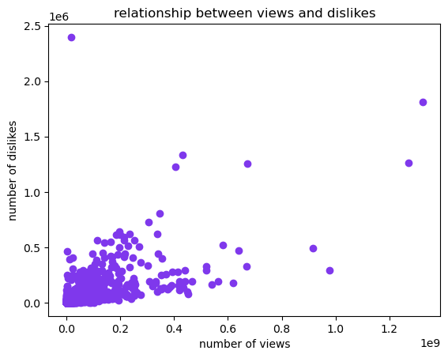

```python
#'df' with the columns 'views' and 'dislikes'
views=df['view_count']
dislikes=df['dislikes']
#calculate the correlation of co-efficient b/w the number of viwes and dislikes
correltion = views.corr(dislikes)
#plot the relationship b/w views and dislikes
plt.scatter(views,dislikes,color='#7F38EC')
plt.xlabel('number of views')
plt.ylabel('number of dislikes')
plt.title("relationship between views and dislikes")
#print the correlation of co-efficient
print("correlation co-efficient b/w views and dislikes :",correltion)
```

the 'views' and 'dislikes' columns are extracted from the DataFrame into separate variables. The corr() method is used to calculate the correlation coefficient between these two variables. A scatter plot is then created using plt.scatter() to visualize the relationship between the number of views and dislikes. By printing the correlation coefficient, we can see a metric that quantifies the strength and direction of the relationship between views and dislikes.

- If the correlation coefficient is close to 0, it indicates a weak or no linear relationship.
- If it is positive, it suggests a positive correlation, meaning as the number of views increases, the number of dislikes also tends to increase.
- If it is negative, it suggests a negative correlation, meaning as the number of views increases, the number of dislikes tends to decrease.

The code then prints the correlation of coeffient of number of views and dislikes of scartter plots is displayed .

**14. Display all the information about the videos that were published in January, and mention the count of videos that were published in January.**

```python
#display a 5 rows from dataset or dataframe
df.head()
```

|  | video_id | title | channel_id | channel_title | published_at | view_count | likes | dislikes | comment_count | tags | description | comments | published_month | published_year | published_date |
| --- | --- | --- | --- | --- | --- | --- | --- | --- | --- | --- | --- | --- | --- | --- | --- |
| 0 | --0bCF-iK2E | Jadon Sancho Magical Skills & Goals | UC6UL29enLNe4mqwTfAyeNuw | Bundesliga | 2021-07-01 10:00:00 | 1048888 | 19515 | 226 | 1319 | football soccer ftbol alemn Bundesliga season ... | Enjoy the best skills and goals from Jadon San... | Respect to Dortmund fans,must be sad losing hi... | Jul | 2021 | 2021-07-01 |
| 1 | --14w5SOEUs | Migos - Avalanche (Official Video) | UCGIelM2Dj3zza3xyV3pL3WQ | MigosVEVO | 2021-06-10 16:00:00 | 15352638 | 359277 | 7479 | 18729 | Migos Avalanche Quality Control Music/Motown R... | Watch the the official video for Migos - "Aval... | Migos just makes me want to live my live to th... | Jun | 2021 | 2021-06-10 |
| 2 | --40TEbZ9Is | Supporting Actress in a Comedy: 73rd Emmys | UClBKH8yZRcM4AsRjDVEdjMg | Television Academy | 2021-09-20 01:03:32 | 925281 | 11212 | 401 | 831 |  | Hannah Waddingham wins the Emmy for Supporting... | Hannah's energy bursts through any screen. Wel... | Sep | 2021 | 2021-09-20 |
| 3 | --4tfbSyYDE | JO1'YOUNG (JO1 ver.)' PERFORMANCE VIDEO | UCsmXiDP8S40uBeJYxvyulmA | JO1 | 2021-03-03 10:00:17 | 2641597 | 39131 | 441 | 3745 | PRODUCE101JAPAN JO1 TheSTAR STA... | JO1'YOUNG (JO1 ver.)' PERFORMANCE VIDEO\n\n---... | youngVer>< REN is really PERFECT. It's not ju... | Mar | 2021 | 2021-03-03 |
| 4 | --DKkzWVh-E | Why Retaining Walls Collapse | UCMOqf8ab-42UUQIdVoKwjlQ | Practical Engineering | 2021-12-07 13:00:00 | 715724 | 32887 | 367 | 1067 | retaining wall New Jersey highway Direct Conne... | One of the most important (and innocuous) part... | Keep up with all my projects here: https://pr... | Dec | 2021 | 2021-12-07 |

```python
#'df' with the 'published_month' column is equal to jan
january_videos = df[df['published_month']=='Jan']

# Display all information about videos published in January
print(january_videos)

# Count the number of videos published in January by using the len method from pandas to count the number of vedios
january_videos_cnt = len(january_videos)

#printing the number of counts of jan vedios it present in variable january_vedios_cnt
print("number of vedios published in january : ",january_videos_cnt)
```

```
          video_id                                              title  \
27     -2Gwm7QfBnE                                    Q&A With Naisha
48     -4sfXSHSxzA           SURPRISING BRENT WITH HIS TIKTOK CRUSH!!
95     -AJD1Fc5rpQ  WE ARE HAVING A BABY! | finding out i'm pregna...
103    -AuJiwjsmWk              Do Ugly Foods Taste Worse? Taste Test
182    -JhqO2KWr5U                                   Schlatt gets fit
...            ...                                                ...
37300  zmzFL5bG-jc  DEVINE MON PERSONNAGE AVANT AKINATOR ! (c'est ...
37329  zpzjex7qwrA  Lampard Sacked Within Days Rorys Misery | Chel...
37345  zqyv-B6mnBM                 Lil Wayne - Ain't Got Time (Audio)
37383  zwfu1-24T7Q  PRADA Cup Day 1 | Full Race Replay | PRADA Cup...
37418  zziBybeSAtw  PELICANS at LAKERS | FULL GAME HIGHLIGHTS | Ja...

                     channel_id       channel_title        published_at  \
27     UCYwNMbogQFzMccPSuy-pPWg           MianTwins 2021-01-21 00:05:47
```

[output cut: 78 more lines]

```python
#it displays only janauary vedios unique values.
january_videos.nunique()
```

```
video_id           2108
title              2106
channel_id         1436
channel_title      1433
published_at       2081
view_count         2107
likes              2086
dislikes           1484
comment_count      1838
tags               1814
description        2051
comments           2100
published_month       1
published_year        1
published_date       31
dtype: int64
```

**THANK YOU**